# Tugas Kelompok

## Uji Formal

```r
#1) Sisaan Menyebar Normal
tseries::jarque.bera.test(sisaan.da)  #tak tolak H0 > sisaan menyebar normal
```

```
##
##  Jarque Bera Test
##
## data:  sisaan.da
## X-squared = 0.054975, df = 2, p-value = 0.9729
```

Selain dengan eksplorasi, asumsi tersebut dapat diuji menggunakan uji formal. Pada tahapan ini uji formal yang digunakan untuk normalitas adalah uji Jarque Bera . Hipotesis pada uji Jarque Bera adalah sebagai berikut.

$H_0$ : Sisaan menyebar normal

$H_1$ : Sisaan tidak menyebar normal

```r
#2) Sisaan saling bebas/tidak ada autokorelasi
Box.test(sisaan.da, type = "Ljung")  #tak tolak H0 > sisaan saling bebas
```

```
##
##  Box-Ljung test
##
## data:  sisaan.da
## X-squared = 0.013183, df = 1, p-value = 0.9086
```

Selanjutnya akan dilakukan uji formal untuk kebebasan sisaan menggunakan uji Ljung-Box. Hipotesis yang digunakan adalah sebagai berikut.

$H_0$ : Sisaan saling bebas

$H_1$ : Sisaan tidak tidak saling bebas

Berdasarkan uji Ljung-Box tersebut, didapat *p-value* sebesar 0.9086 yang lebih besar dari taraf nyata 5% sehingga tak tolak $H_0$ dan menandakan bahwa sisaan saling bebas. Hal ini sesuai dengan hasil eksplorasi.

```r
#3) Sisaan homogen
library(lmtest)
Box.test((sisaan.da)^2, type = "Ljung")  #tak tolak H0 > sisaan homogen
```

```
##
##  Box-Ljung test
##
## data:  (sisaan.da)^2
## X-squared = 2.9184, df = 1, p-value = 0.08758
```

Hipotesis yang digunakan untuk uji kehomogenan ragam adalah sebagai berikut.

$H_0$ : Ragam sisaan homogen

$H_1$ : Ragam sisaan tidak homogen

Berdasarkan uji Ljung-Box terhadap sisaan kuadrat tersebut, didapat *p-value* sebesar 0.08758 yang lebih besar dari taraf nyata 5% sehingga tak tolak $H_0$ dan menandakan bahwa ragam sisaan homogen.

```r
#4) Nilai tengah sisaan sama dengan nol
t.test(sisaan.da, mu = 0, conf.level = 0.95)  #tak tolak h0 > nilai tengah sisaan sama dengan 0
```

```
##
##  One Sample t-test
##
## data:  sisaan.da
## t = 1.6048, df = 174, p-value = 0.1104
## alternative hypothesis: true mean is not equal to 0
## 95 percent confidence interval:
##  -0.04015695  0.38952672
## sample estimates:
## mean of x
## 0.1746849
```

Terakhir, dengan uji-t, akan dicek apakah nilai tengah sisaan sama dengan nol. Hipotesis yang diujikan sebagai berikut.

$H_0$ : nilai tengah sisaan sama dengan 0

$H_1$ : nilai tengah sisaan tidak sama dengan 0

Berdasarkan uji-ttersebut, didapat *p-value* sebesar 0.1104 yang lebih besar dari taraf nyata 5% sehingga tak tolak $H_0$ dan menandakan bahwa nilai tengah sisaan sama dengan nol. Hal ini sama dengan hasil eksplorasi.

# Overfitting

Tahapan selanjutnya adalah *overfitting* dilakukan dengan menaikkan orde AR(p) dan MA(q) dari model ARIMA(2,1,1) untuk melihat apakah terdapat model lain yang lebih baik dari model saat ini. Kandidat model *overfitting* adalah ARIMA(3,1,1) dan ARIMA(2,1,2).

## Model ARIMA(3,1,1)

```r
model.overfit1=Arima(train.diff1, order=c(3,1,1),method="ML")
summary(model.overfit1) #AIC=635.81
```

```
## Series: train.diff1
## ARIMA(3,1,1)
##
## Coefficients:
##          ar1      ar2      ar3      ma1
##       0.1753  -0.2010  -0.1328  -1.0000
## s.e.  0.0779   0.0773   0.0795   0.0196
##
## sigma^2 = 2.116:  log likelihood = -312.9
## AIC=635.81   AICc=636.17   BIC=651.61
##
## Training set error measures:
##                     ME     RMSE      MAE MPE MAPE      MASE        ACF1
## Training set 0.1758788 1.433743 1.113642 Inf  Inf 0.7276517 0.005863446
```

```r
lmtest::coeftest(model.overfit1) #terdapat parameter tidak signifikan
```

```
##
## z test of coefficients:
##
##      Estimate Std. Error  z value Pr(>|z|)
## ar1  0.175323   0.077930   2.2497  0.02447 *
## ar2 -0.200999   0.077305  -2.6001  0.00932 **
## ar3 -0.132782   0.079460  -1.6710  0.09471 .
## ma1 -1.000000   0.019564 -51.1148  < 2e-16 ***
## ---
## Signif. codes:  0 '***' 0.001 '**' 0.01 '*' 0.05 '.' 0.1 ' ' 1
```

## Model ARIMA(2,1,2)

```r
model.overfit2=Arima(train.diff1, order=c(2,1,2),method="ML")
summary(model.overfit2) #AIC=623.68
```

```
## Series: train.diff1
## ARIMA(2,1,2)
##
## Coefficients:
##          ar1      ar2      ma1     ma2
##       1.0429  -0.3267  -1.9652  0.9726
## s.e.  0.0777   0.0766   0.0461  0.0463
##
## sigma^2 = 1.959:  log likelihood = -306.84
## AIC=623.68   AICc=624.04   BIC=639.48
##
## Training set error measures:
##                    ME     RMSE      MAE MPE MAPE      MASE       ACF1
## Training set 0.157889 1.379404 1.085657 NaN  Inf 0.7093664 0.03210205
```

```r
lmtest::coeftest(model.overfit2) ##seluruh parameter signifikan
```

```
##
## z test of coefficients:
##
##      Estimate Std. Error  z value  Pr(>|z|)
## ar1  1.042912   0.077748  13.4139 < 2.2e-16 ***
## ar2 -0.326698   0.076559  -4.2673 1.979e-05 ***
## ma1 -1.965242   0.046089 -42.6398 < 2.2e-16 ***
## ma2  0.972600   0.046306  21.0036 < 2.2e-16 ***
## ---
## Signif. codes:  0 '***' 0.001 '**' 0.01 '*' 0.05 '.' 0.1 ' ' 1
```

Berdasarkan kedua model hasil *overfitting* di atas, model ARIMA(3,1,1) dan ARIMA(2,1,2) memiliki AIC yang lebih kecil dibandingkan dengan model ARIMA(2,1,1). Parameter model ARIMA(3,1,1) tidak seluruhnya signifikan. Sedangkan, parameter model ARIMA(2,1,2) seluruhnya signifikan. Oleh karena itu, model ARIMA(2,1,2) akan digunakan untuk melakukan peramalan.

# Peramalan

## Peramalan Menggunakan Model ARIMA(2,1,1)

Peramalan dilakukan menggunakan fungsi `forecast()` . Contoh peramalan berikut ini dilakukan untuk 36 periode ke depan.

```r
#---FORECAST---#
ramalan.da <- forecast::forecast(model5.da, h = 36)
ramalan.da
```

```
##     Point Forecast     Lo 80    Hi 80     Lo 95    Hi 95
## 177    -0.72735321 -2.607979 1.153272 -3.603522 2.148815
## 178     0.42107153 -1.500201 2.342344 -2.517261 3.359404
## 179     0.30251522 -1.646919 2.251950 -2.678888 3.283918
## 180     0.02123590 -1.933520 1.975992 -2.968306 3.010778
## 181    -0.00943142 -1.964944 1.946081 -3.000130 2.981267
## 182     0.04731663 -1.908923 2.003557 -2.944494 3.039128
## 183     0.06572706 -1.890507 2.021961 -2.926075 3.057529
## 184     0.05676451 -1.899441 2.012970 -2.934994 3.048523
## 185     0.05081883 -1.905378 2.007016 -2.940926 3.042564
## 186     0.05161637 -1.904592 2.007824 -2.940145 3.043378
## 187     0.05311000 -1.903102 2.009322 -2.938659 3.044879
## 188     0.05323523 -1.902976 2.009446 -2.938531 3.045002
## 189     0.05292624 -1.903283 2.009136 -2.938838 3.044691
## 190     0.05283534 -1.903374 2.009045 -2.938929 3.044600
```

[output cut: 22 more lines]

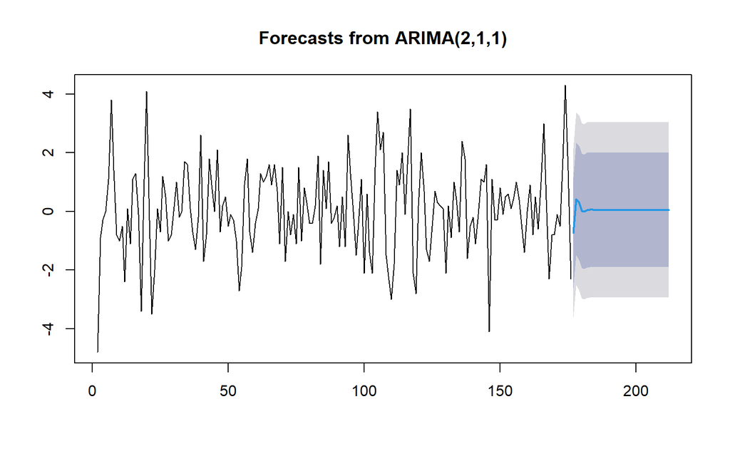

```r
data.ramalan.da <- ramalan.da$mean
plot(ramalan.da)
```

Berdasarkan hasil plot ramalan di atas, dapat dilihat bahwa ramalan ARIMA(2,1,1) cenderung stabil hingga akhir periode. Selanjutnya, dapat dicari nilai akurasi antara hasil ramalan dengan data uji sebagai berikut.

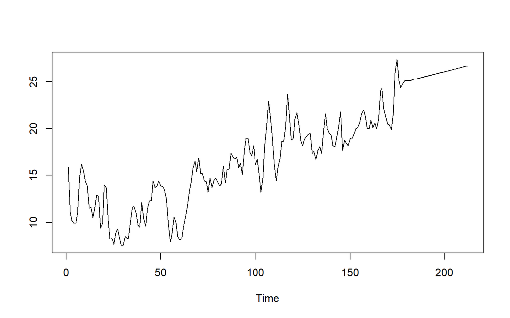

```r
pt_1 <- train.ts[176] #nilai akhir data latih
hasil.forc.Diff <- data.ramalan.da
hasil <- diffinv(hasil.forc.Diff, differences = 1) + pt_1

#has.1 sama hasilnta dengan: cumsum(c(pt_1,hasil.forc.Diff))
ts.plot(train.ts,hasil)
```

```r
perbandingan.da<-matrix(data=c(head(test.ts, n=36), hasil[-1]),
                     nrow = 36, ncol = 2)
colnames(perbandingan.da)<-c("Aktual","Hasil Forecast")
perbandingan.da
```

```
##       Aktual Hasil Forecast
##  [1,]   24.7       24.37265
##  [2,]   23.7       24.79372
##  [3,]   23.6       25.09623
##  [4,]   21.5       25.11747
##  [5,]   21.9       25.10804
##  [6,]   23.7       25.15535
##  [7,]   24.6       25.22108
##  [8,]   22.2       25.27785
##  [9,]   21.5       25.32867
## [10,]   21.4       25.38028
## [11,]   21.5       25.43339
## [12,]   21.1       25.48663
## [13,]   21.9       25.53955
## [14,]   21.5       25.59239
```

[output cut: 22 more lines]

```r
accuracy(ts(hasil[-1]), head(test.ts, n=36))
```

```
##                 ME     RMSE      MAE       MPE     MAPE    ACF1 Theil's U
## Test set -3.650575 3.927688 3.668761 -16.80135 16.87498 0.59057  3.651974
```

Model tersebut merupakan model dengan akurasi peramalan baik dengan nilai MAPE = 16.87% yang kurang dari 20%.

## Peramalan Menggunakan Model Overfitting -> ARIMA(2,1,2)

Peramalan dilakukan menggunakan fungsi `forecast()` . Contoh peramalan berikut ini dilakukan untuk 36 periode ke depan.

```r
#---FORECAST---#
ramalan.da <- forecast::forecast(model.overfit2, h = 36)
ramalan.da
```

```
##     Point Forecast     Lo 80     Hi 80     Lo 95    Hi 95
## 177     -1.4301151 -3.224091 0.3638611 -4.173765 1.313535
## 178     -0.6660079 -2.465428 1.1334118 -3.417983 2.085967
## 179     -0.1533008 -2.002618 1.6960163 -2.981587 2.674986
## 180      0.1317753 -1.778222 2.0417726 -2.789313 3.052864
## 181      0.2615843 -1.679411 2.2025796 -2.706912 3.230080
## 182      0.3038299 -1.646549 2.2542088 -2.679017 3.286677
## 183      0.3054799 -1.646272 2.2572322 -2.679468 3.290427
## 184      0.2933993 -1.658353 2.2451513 -2.691548 3.278346
## 185      0.2802611 -1.671829 2.2323515 -2.705204 3.265726
## 186      0.2705059 -1.682260 2.2232715 -2.715991 3.257003
## 187      0.2646243 -1.688912 2.2181607 -2.723052 3.252300
## 188      0.2616772 -1.692596 2.2159503 -2.727125 3.250480
## 189      0.2605253 -1.694419 2.2154695 -2.729304 3.250354
## 190      0.2602867 -1.695274 2.2158471 -2.730485 3.251058
```

[output cut: 22 more lines]

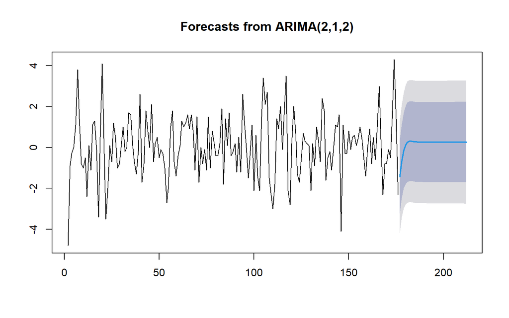

```r
data.ramalan.da <- ramalan.da$mean
plot(ramalan.da)
```

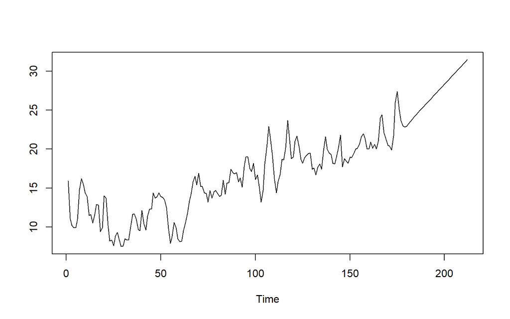

```r
pt_1 <- train.ts[176] #nilai akhir data latih
hasil.forc.Diff <- data.ramalan.da
hasil <- diffinv(hasil.forc.Diff, differences = 1) + pt_1

#has.1 sama hasilnta dengan: cumsum(c(pt_1,hasil.forc.Diff))
ts.plot(train.ts,hasil)
```

```r
perbandingan.da<-matrix(data=c(head(test.ts, n=36), hasil[-1]),
                     nrow = 36, ncol = 2)
colnames(perbandingan.da)<-c("Aktual","Hasil Forecast")
perbandingan.da
```

```
##       Aktual Hasil Forecast
##  [1,]   24.7       23.66988
##  [2,]   23.7       23.00388
##  [3,]   23.6       22.85058
##  [4,]   21.5       22.98235
##  [5,]   21.9       23.24394
##  [6,]   23.7       23.54777
##  [7,]   24.6       23.85325
##  [8,]   22.2       24.14664
##  [9,]   21.5       24.42691
## [10,]   21.4       24.69741
## [11,]   21.5       24.96204
## [12,]   21.1       25.22371
## [13,]   21.9       25.48424
## [14,]   21.5       25.74453
```

[output cut: 22 more lines]

```r
accuracy(ts(hasil[-1]), head(test.ts, n=36))
```

```
##                 ME     RMSE      MAE       MPE     MAPE      ACF1 Theil's U
## Test set -4.786816 5.777138 4.974296 -22.09961 22.87523 0.8648433  5.385868
```

Model tersebut merupakan model dengan akurasi peramalan biasa dengan nilai MAPE = 22.87% yang kurang dari 50%.

# Kesimpulan

Jadi, model overfitting ARIMA(2,1,2) memilihi nilai AIC yang lebih kecil dari model tentatif ARIMA(2,1,1). Tetapi, peramalan menggunakan model tentatif ARIMA(2,1,1) memilihi nilaI MAPE yang lebih kecil dari model overfitting ARIMA(2,1,2).